# Question 1 (Normal Distribution)

```python
%matplotlib inline
import numpy as np
import matplotlib.pyplot as plt
import scipy
from scipy.stats import expon
from scipy.stats import poisson
```

## Cumulative Density Function (CDF) and Z Score

```python
probability = stats.norm.cdf(13,10,2)
probability
zScore = stats.norm.ppf(probability)
zScore
```

```
1.4999999999999996
```

z score indicates standard deviations from the mean, + above and - below

# Question 2 (Exponential Distribution)

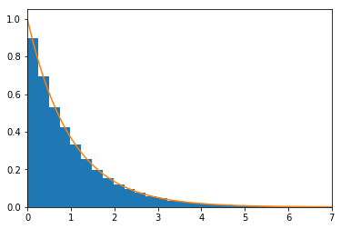

```python
fig, ax = plt.subplots(1, 1)
rv = expon.rvs(loc=0, scale=1, size=100000)
ax.hist(rv, 50, density=True, histtype='stepfilled')
plt.xlim([0,7])
x = np.linspace(0,7,1000)
ax.plot(x, stats.expon.pdf(x, loc=0, scale=1))
plt.show()
```

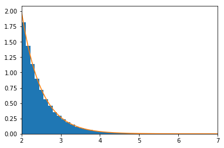

```python
fig, ax = plt.subplots(1, 1)
rv = expon.rvs(loc=2, scale=0.5, size=100000)
ax.hist(rv, 50, density=True, histtype='stepfilled')
plt.xlim([2,7])
x = np.linspace(0,7,1000)
ax.plot(x, stats.expon.pdf(x, loc=2, scale=0.5))
plt.show()
```

The location paramter, determines where the beginning of the distribution is. If positive it shifts the distribution to the right of the origin.

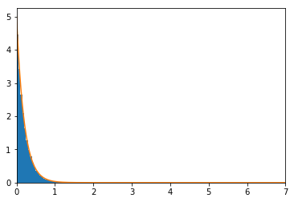

```python
fig, ax = plt.subplots(1, 1)
rv = expon.rvs(loc=0, scale=0.2, size=100000)
ax.hist(rv, 50, density=True, histtype='stepfilled')
plt.xlim([0,7])
x = np.linspace(0,7,1000)
ax.plot(x, stats.expon.pdf(x, loc=0, scale=0.2))
plt.show()
```

If we keep loc as 0 and tweak the scale value we notice a pattern. A decrease in the scale value shrinks the plot, and an increase stretches the plot.

# Question 3 (Exploring the Exponential Distribution)

## Hypothetical Situation

For this example, we will look at the number of times a Youtube video gets viewed. We will use the exponential distribution to model the time between views, taking lamda to be 200 views per hour.

\begin{align*} \lambda = 200/60 = 3.33 \end{align*} \begin{align*} \theta = 1/33.3 = 0.30 \end{align*}

Our statistical question is therefore what is probability of the video getting viewed at least every four minutes i.e there's a gap of four minutes between each view.

## Mathematical Integral

\begin{align*} \int_{0}^{x} \lambda e^{- \lambda t} dt \end{align*}

## Calculating the Probability using CDF

\begin{align*} 1 - P(X < 4) \end{align*}

```python
p = stats.expon.cdf(4, loc=3.33, scale=0.30)
1-p
```

```
0.10717059875230672
```

## Calculating Sigma

\begin{align*} \sigma = 1/\lambda = 1/3.33 = 0.30 \end{align*}

Standard Deviation is related to the lambda value. The exponential distribution is unique in the sense that mean and standard deviation are the same, they both have values of:

\begin{align*} 1/\lambda \end{align*}

# Question 4 (Poisson Distribution)

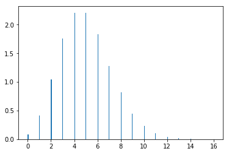

```python
fig, ax = plt.subplots(1, 1)
rv = np.random.poisson(5, 100000)
plt.hist(rv, 200, normed=True)
plt.show()
```

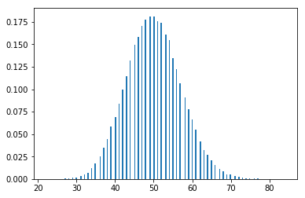

```python
fig, ax = plt.subplots(1, 1)
rv = np.random.poisson(50, 100000)
plt.hist(rv, 200, normed=True)
plt.show()
```

Poisson has one paramaeter lambda, that indicates the average number of events in a given interval. The greater the value of lambda, the more spread out the distribution is.

## Statistical Question

The ATM at the HUB gets an average of 4 visitors per hour. What is the probability 6 visitors visit the ATM in the next hour?

```python
poisson.pmf(6,4)
```

```
0.10419563456702102
```

There's a 10% chance of 6 customers coming in the next hour.

## Discrete Distributions

A discrete distribution means that the probability of something occuring has a finite value. Therefore it is possible to calculate:

\begin{align*} P(X = x) \end{align*}

The main difference between discrete and continuous distributions is the fact that discrete distributions have a finite amount of outcomes.

The parameters for Discrete Distributions are also discrete as they take on one value, and not a set of values in a range. In the case of a poisson distribution, the mean value is discrete it doesn't take on a range of values.